# Statistics for Forest Ecologists

A hands-on module with R and the Ecological Statistics Toolkit

Hasna Afifah (with Claude assistance)

# 1 About this module

**Who it is for.** Ecologists and foresters who collect plot data and want to choose, run and report the right analysis - without a statistics degree.

**What you will learn.**

1. How to choose a method from the type of question and the type of data.
2. How to check normality and transform a variable.
3. How to compare groups (t-tests, ANOVA, and their rank-based alternatives).
4. How to measure correlation (Pearson vs Spearman) and test categorical variables (chi-square).
5. How to model a response (linear models, GLMs, and random factors).
6. How to summarise many variables at once (PCA, NMDS, PERMANOVA, clustering).

**How to use it.** Every example is shown twice: as R code you can copy, and as a recipe for the Shiny app (boxes marked **In the app**). Start the app with `shiny::runApp()` from the repository folder, go to **1. Data** and click **Load example data**.

## 1.1 The example data

Both datasets are **simulated** (script: `data-raw/make_example_data.R`). They imitate a plot survey in a lowland tropical forest landscape with four forest types, 30 plots each. Because we built them, we know the true patterns - which makes them ideal for learning. Do not cite the numbers as real findings.

```r
d    <- read.csv("../data/forest_plots.csv")
comm <- read.csv("../data/tree_community.csv", check.names = FALSE)
d$forest_type <- factor(d$forest_type)
str(d, vec.len = 2)
```

```
#> 'data.frame':    120 obs. of  21 variables:
#>  $ plot_id              : chr  "P016" "P104" ...
#>  $ site                 : chr  "S08" "S08" ...
#>  $ forest_type          : Factor w/ 4 levels "Agroforest","Logged",..: 4 3 4 1 1 ...
#>  $ elevation_m          : int  360 129 300 839 663 ...
#>  $ slope_deg            : num  7 8.9 2 11.4 11.8 ...
#>  $ canopy_cover_pct     : num  93.9 54.8 93.1 68.5 64.1 ...
#>  $ soil_pH              : num  4.4 5.47 4.25 5.17 5.11 ...
#>  $ soil_C_pct           : num  5.68 2.31 4.19 2.71 3.02 ...
#>  $ soil_N_pct           : num  0.414 0.163 0.32 0.227 0.226 ...
#>  $ litter_depth_cm      : num  5 2.3 4.2 4.8 3 ...
#>  $ basal_area_m2ha      : num  38 23.1 31.2 18.5 23.8 ...
#>  $ tree_density_ha      : int  466 591 550 428 560 ...
#>  $ agb_Mg_ha            : num  319 125 ...
#>  $ species_richness     : int  10 2 12 6 1 ...
#>  $ seedling_count       : int  20 10 5 15 32 ...
#>  $ understory_cover_pct : num  33.3 61.8 36.8 63.5 63.4 ...
#>  $ hornbill_present     : int  1 1 1 1 0 ...
#>  $ fire_history         : chr  "Burned" "Burned" ...
#>  $ soil_moisture_dry_pct: num  31.5 23.6 28.4 25.2 27.7 ...
#>  $ soil_moisture_wet_pct: num  35.4 23.5 35.6 29.3 30.6 ...
#>  $ canopy_height_m      : num  24.4 21.8 26.4 16.9 27.6 ...
```

| Variable | Meaning | Type |
| --- | --- | --- |
| `site` | 12 sites, 10 plots each | grouping (random factor) |
| `forest_type` | Primary, Logged, Agroforest, Plantation | categorical |
| `elevation_m`, `slope_deg` | Topography | continuous |
| `canopy_cover_pct` | Canopy cover (%) | percentage |
| `soil_pH`, `soil_C_pct`, `soil_N_pct`, `litter_depth_cm` | Soil | continuous |
| `basal_area_m2ha`, `tree_density_ha` | Stand structure | continuous |
| `agb_Mg_ha` | Above-ground biomass | continuous, right-skewed |
| `canopy_height_m` | Canopy height (varies between sites) | continuous |
| `species_richness` | Tree species per plot | count |
| `seedling_count` | Seedlings per plot | count, overdispersed |
| `understory_cover_pct` | Understory cover (%) | percentage |
| `hornbill_present` | Hornbill detected (1) or not (0) | binary |
| `fire_history` | Burned / Unburned | categorical |
| `soil_moisture_dry_pct`, `soil_moisture_wet_pct` | Same plot, two seasons | paired |

`tree_community.csv` holds stem counts of 14 tree taxa in 40 plots (10 per forest type) for the multivariate section.

# 2 Which method should I use?

Two questions decide almost everything:

1. **What is my question?** Comparing groups, relating two variables, predicting a response, or summarising many variables.
2. **What kind of data is my response?** Continuous, count, binary, proportion - and does it meet the assumptions of the classical test?

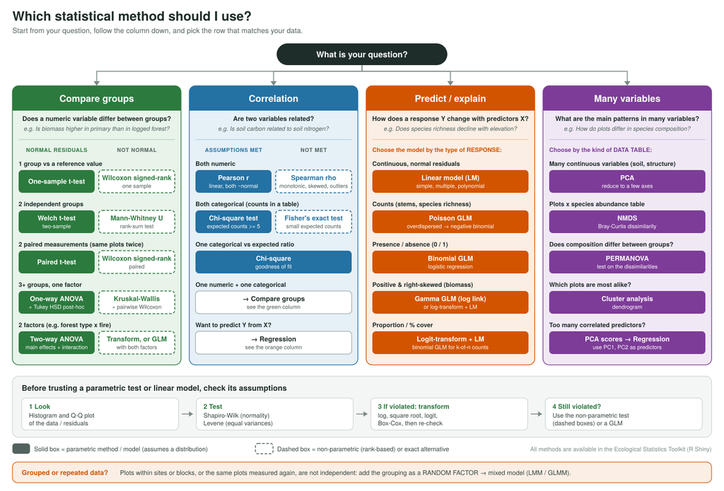

> **In the app:** the **Guide** tab shows this chart and a short questionnaire that returns the recommended method, the tab where it lives, and the R code.

Three ideas run through the whole module:

- **Parametric tests** (t-test, ANOVA, Pearson, linear regression) assume that the *residuals* - what is left after removing group means or the fitted line - are roughly normal with similar spread. They are the most powerful choice when that holds.
- When it does not hold you have three options: **transform** the variable, switch to a **rank-based (non-parametric)** test, or use a **GLM** that matches the data type (counts, presence/absence).
- Most methods here assume **independent observations**. Plots clustered in sites, or the same trees measured every year, are not independent: use a paired test, or add the grouping as a **random factor** (Section 6.7).

# 3 Normality and transformation

**Ecological question.** Above-ground biomass (AGB) usually has many small values and a few very large ones. Can we make it “normal enough” for a t-test or a linear model?

## 3.1 Look first, test second

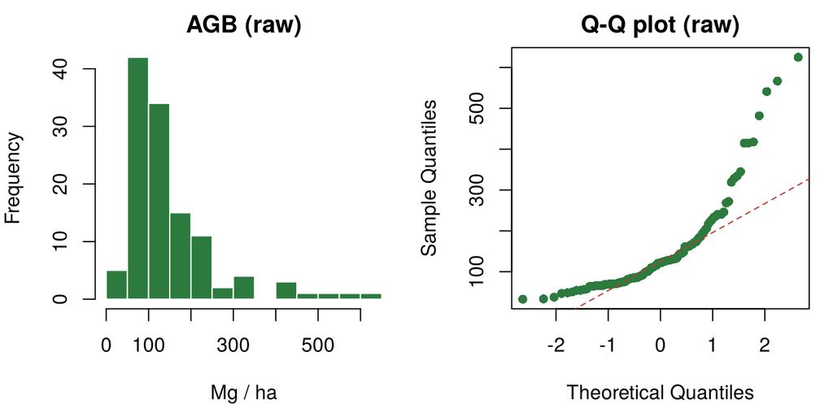

```r
par(mfrow = c(1, 2), mar = c(4, 4, 2, 1))
hist(d$agb_Mg_ha, breaks = 20, col = green, border = "white",
     main = "AGB (raw)", xlab = "Mg / ha")
qqnorm(d$agb_Mg_ha, pch = 16, col = green, main = "Q-Q plot (raw)")
qqline(d$agb_Mg_ha, col = red, lty = 2)
```

```r
shapiro.test(d$agb_Mg_ha)
```

```
#>
#>  Shapiro-Wilk normality test
#>
#> data:  d$agb_Mg_ha
#> W = 0.77051, p-value = 2.051e-12
```

The histogram has a long right tail and the Q-Q points bend away from the line. Shapiro-Wilk agrees: p < 0.001, so we reject normality. (For Shapiro-Wilk, **p < 0.05 means “not normal”**.)

## 3.2 Transform and re-check

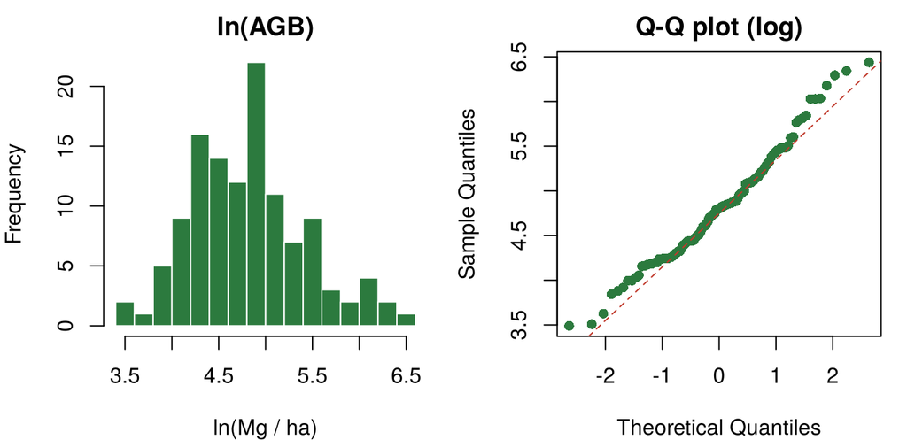

```r
d$agb_log <- log(d$agb_Mg_ha)
par(mfrow = c(1, 2), mar = c(4, 4, 2, 1))
hist(d$agb_log, breaks = 20, col = green, border = "white",
     main = "ln(AGB)", xlab = "ln(Mg / ha)")
qqnorm(d$agb_log, pch = 16, col = green, main = "Q-Q plot (log)")
qqline(d$agb_log, col = red, lty = 2)
```

```r
shapiro.test(d$agb_log)
```

```
#>
#>  Shapiro-Wilk normality test
#>
#> data:  d$agb_log
#> W = 0.97876, p-value = 0.0546
```

After the log transformation the points follow the line and Shapiro-Wilk no longer rejects normality (p = 0.055).

## 3.3 A transformation cheat-sheet

| Data | Typical shape | Try | Often better |
| --- | --- | --- | --- |
| Biomass, DBH, basal area, concentrations | right-skewed, > 0 | `log(x)`; `sqrt(x)` if mild | Gamma GLM |
| Counts (stems, seedlings, species) | right-skewed, zeros | `sqrt(x)`, `log(x + 1)` | Poisson / negative binomial GLM |
| Proportions, % cover | squeezed at 0 and 100 | logit, arcsine-square-root | binomial GLM |
| Left-skewed | long left tail | `x^2` | - |
| Unsure | any | Box-Cox (x > 0), Yeo-Johnson | - |

Box-Cox finds the power transformation that best normalises the data:

```r
lambda <- car::powerTransform(d$agb_Mg_ha)$lambda
lambda
```

```
#> d$agb_Mg_ha
#>  -0.2685395
```

A lambda near 0 means “use the log”; near 0.5 the square root; near 1 no transformation. Here lambda = -0.27, close to the log.

**Three cautions.**

1. What must be normal is the **residuals** (or the values *within* each group), not the pooled raw variable. A variable that differs strongly between forest types can look non-normal overall and still be fine.
2. After a log transformation, differences are **ratios**: back-transforming a mean of logs gives the *geometric* mean, not the arithmetic mean.
3. With large samples Shapiro-Wilk flags trivial deviations. Trust the Q-Q plot.

> **In the app:** **3. Transform** - choose `agb_Mg_ha`, pick a transformation, compare the before/after histograms and Q-Q plots, read the ranking table of all transformations, then click **Add transformed column to data** so the new variable can be used in every other tab.

# 4 Comparing groups

## 4.1 One sample against a reference value

**Question.** Suppose liming is recommended when soil pH is below 5.5. Is mean soil pH in our plots different from 5.5?

```r
t.test(d$soil_pH, mu = 5.5)
```

```
#>
#>  One Sample t-test
#>
#> data:  d$soil_pH
#> t = -13.836, df = 119, p-value < 2.2e-16
#> alternative hypothesis: true mean is not equal to 5.5
#> 95 percent confidence interval:
#>  4.870239 5.027928
#> sample estimates:
#> mean of x
#>  4.949083
```

Mean pH is 4.95, and the 95% confidence interval does not include 5.5: the soils are significantly more acidic than the threshold (p < 0.001). Non-parametric alternative: `wilcox.test(d$soil_pH, mu = 5.5)`.

## 4.2 Two independent groups: t-test or Mann-Whitney

**Question.** Is basal area higher in primary than in logged forest?

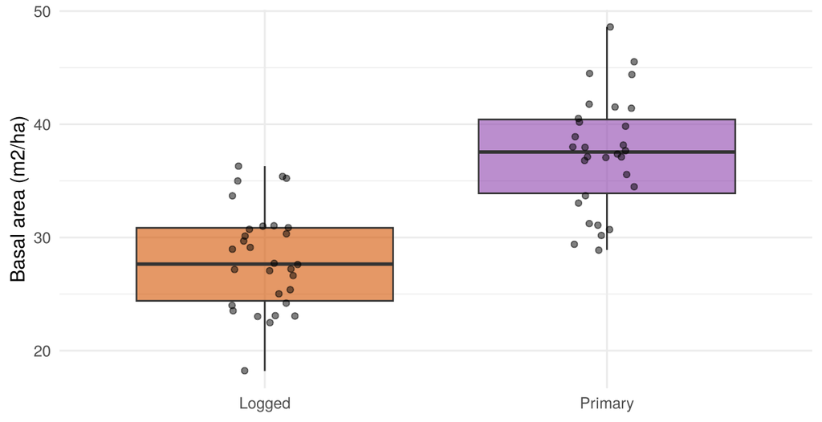

```r
two <- droplevels(subset(d, forest_type %in% c("Primary", "Logged")))
ggplot(two, aes(forest_type, basal_area_m2ha, fill = forest_type)) +
  geom_boxplot(alpha = 0.6, outlier.shape = NA) + geom_jitter(width = 0.1, alpha = 0.5) +
  scale_fill_manual(values = pal) + labs(x = NULL, y = "Basal area (m2/ha)") +
  theme(legend.position = "none")
```

```r
tapply(two$basal_area_m2ha, two$forest_type, shapiro.test)   # normal within each group?
```

```
#> $Logged
#>
#>  Shapiro-Wilk normality test
#>
#> data:  X[[i]]
#> W = 0.97052, p-value = 0.5534
#>
#>
#> $Primary
#>
#>  Shapiro-Wilk normality test
#>
#> data:  X[[i]]
#> W = 0.97212, p-value = 0.5988
```

```r
tt <- t.test(basal_area_m2ha ~ forest_type, data = two)       # Welch's t-test (default)
tt
```

```
#>
#>  Welch Two Sample t-test
#>
#> data:  basal_area_m2ha by forest_type
#> t = -7.6316, df = 57.233, p-value = 2.751e-10
#> alternative hypothesis: true difference in means between group Logged and group Primary is not equal to 0
#> 95 percent confidence interval:
#>  -11.782089  -6.884578
#> sample estimates:
#>  mean in group Logged mean in group Primary
#>              28.09333              37.42667
```

Basal area is normal within each group, so the t-test is appropriate. R’s default is **Welch’s** t-test, which does not assume equal variances - keep that default. Primary forest has on average 9.3 m2/ha more basal area than logged forest (p < 0.001).

**When the data are not normal**, compare ranks instead. Seedling counts are strongly skewed:

```r
tapply(d$seedling_count, d$fire_history, median)
```

```
#>   Burned Unburned
#>       12        8
```

```r
wilcox.test(seedling_count ~ fire_history, data = d)
```

```
#>
#>  Wilcoxon rank sum test with continuity correction
#>
#> data:  seedling_count by fire_history
#> W = 2339.5, p-value = 0.00424
#> alternative hypothesis: true location shift is not equal to 0
```

Burned plots have a higher median seedling count than unburned plots (Mann-Whitney U test, p = 0.004).

## 4.3 Two paired measurements

**Question.** Each plot was measured in the dry and in the wet season. Is soil moisture higher in the wet season?

Because the two values come from the *same plot*, they are not independent. The paired t-test analyses the within-plot **differences**, which removes the large plot-to-plot variation.

```r
dif <- d$soil_moisture_wet_pct - d$soil_moisture_dry_pct
shapiro.test(dif)                                   # the differences must be normal
```

```
#>
#>  Shapiro-Wilk normality test
#>
#> data:  dif
#> W = 0.98559, p-value = 0.2321
```

```r
t.test(d$soil_moisture_wet_pct, d$soil_moisture_dry_pct, paired = TRUE)
```

```
#>
#>  Paired t-test
#>
#> data:  d$soil_moisture_wet_pct and d$soil_moisture_dry_pct
#> t = 20.361, df = 119, p-value < 2.2e-16
#> alternative hypothesis: true mean difference is not equal to 0
#> 95 percent confidence interval:
#>  5.734721 6.970279
#> sample estimates:
#> mean difference
#>          6.3525
```

Soil moisture is on average 6.4 percentage points higher in the wet season. If the differences were not normal: `wilcox.test(wet, dry, paired = TRUE)`.

A common mistake is to analyse paired data with an unpaired test - it throws away the pairing and loses power.

## 4.4 Three or more groups: one-way ANOVA

**Question.** Does basal area differ among the four forest types?

Running six separate t-tests would inflate the chance of a false positive. ANOVA asks one question first - *is there any difference at all?* - and a post-hoc test then identifies which pairs differ.

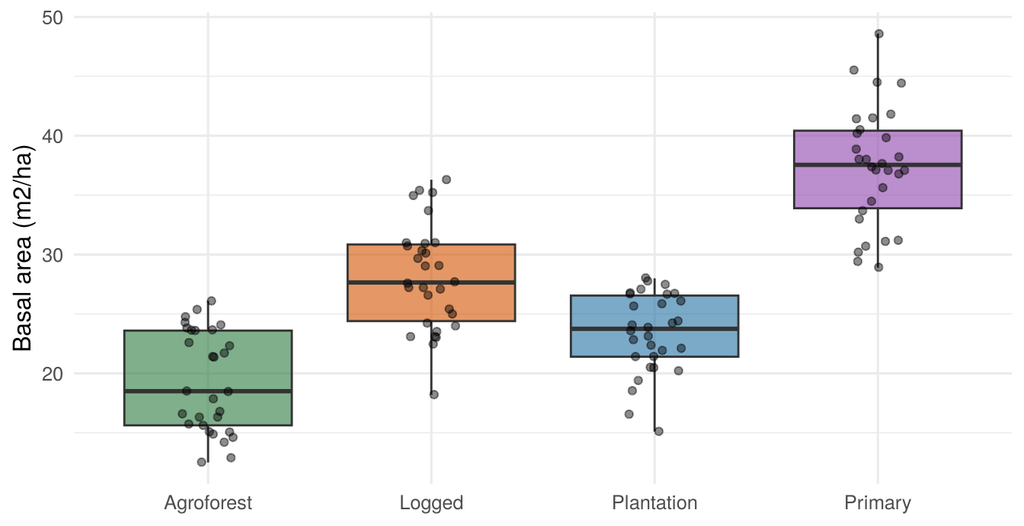

```r
ggplot(d, aes(forest_type, basal_area_m2ha, fill = forest_type)) +
  geom_boxplot(alpha = 0.6, outlier.shape = NA) + geom_jitter(width = 0.12, alpha = 0.45) +
  scale_fill_manual(values = pal) + labs(x = NULL, y = "Basal area (m2/ha)") +
  theme(legend.position = "none")
```

```r
fit <- aov(basal_area_m2ha ~ forest_type, data = d)
summary(fit)
```

```
#>              Df Sum Sq Mean Sq F value Pr(>F)
#> forest_type   3   5451  1817.0    97.7 <2e-16 ***
#> Residuals   116   2157    18.6
#> ---
#> Signif. codes:  0 '***' 0.001 '**' 0.01 '*' 0.05 '.' 0.1 ' ' 1
```

**Check the assumptions on the residuals:**

```r
shapiro.test(residuals(fit))                           # normal residuals?
```

```
#>
#>  Shapiro-Wilk normality test
#>
#> data:  residuals(fit)
#> W = 0.99066, p-value = 0.5942
```

```r
car::leveneTest(basal_area_m2ha ~ forest_type, data = d)  # equal variances?
```

|  | Df | F value | Pr(>F) |
| --- | --- | --- | --- |
| group | 3 | 1.321988 | 0.2706367 |
|  | 116 | NA | NA |

Both p-values are above 0.05, so the assumptions hold. **Which groups differ?**

```r
TukeyHSD(fit)
```

```
#>   Tukey multiple comparisons of means
#>     95% family-wise confidence level
#>
#> Fit: aov(formula = basal_area_m2ha ~ forest_type, data = d)
#>
#> $forest_type
#>                            diff       lwr       upr     p adj
#> Logged-Agroforest      8.750000  5.847466 11.652534 0.0000000
#> Plantation-Agroforest  4.026667  1.124133  6.929201 0.0024740
#> Primary-Agroforest    18.083333 15.180799 20.985867 0.0000000
#> Plantation-Logged     -4.723333 -7.625867 -1.820799 0.0002593
#> Primary-Logged         9.333333  6.430799 12.235867 0.0000000
#> Primary-Plantation    14.056667 11.154133 16.959201 0.0000000
```

**How to report it.** “Basal area differed among forest types (one-way ANOVA, F(3, 116) = 97.7, p < 0.001, eta-squared = 0.72). Tukey’s HSD showed that all pairs of forest types differed, with primary forest highest.”

**If assumptions fail:**

- unequal variances -> Welch’s ANOVA: `oneway.test(y ~ group, data = d)`
- non-normal residuals -> transform, or Kruskal-Wallis:

```r
kruskal.test(seedling_count ~ forest_type, data = d)
```

```
#>
#>  Kruskal-Wallis rank sum test
#>
#> data:  seedling_count by forest_type
#> Kruskal-Wallis chi-squared = 29.038, df = 3, p-value = 2.198e-06
```

```r
pairwise.wilcox.test(d$seedling_count, d$forest_type, p.adjust.method = "holm")
```

```
#>
#>  Pairwise comparisons using Wilcoxon rank sum test with continuity correction
#>
#> data:  d$seedling_count and d$forest_type
#>
#>            Agroforest Logged Plantation
#> Logged     0.4154     -      -
#> Plantation 0.0109     0.0053 -
#> Primary    0.0044     0.0515 1.2e-05
#>
#> P value adjustment method: holm
```

## 4.5 Two factors: two-way ANOVA

**Question.** Does basal area depend on forest type, on fire history, and does the effect of fire depend on the forest type (interaction)?

```r
fit2 <- aov(basal_area_m2ha ~ forest_type * fire_history, data = d)
car::Anova(fit2, type = 2)
```

|  | Sum Sq | Df | F value | Pr(>F) |
| --- | --- | --- | --- | --- |
| forest_type | 4429.3402872 | 3 | 78.3317446 | 0.0000000 |
| fire_history | 0.8974284 | 1 | 0.0476124 | 0.8276683 |
| forest_type:fire_history | 45.4690239 | 3 | 0.8041080 | 0.4941358 |
| Residuals | 2111.0475477 | 112 | NA | NA |

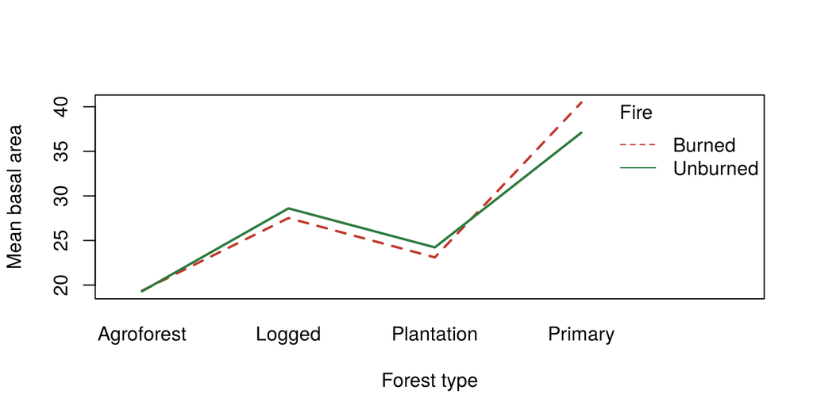

```r
with(d, interaction.plot(forest_type, fire_history, basal_area_m2ha,
                         col = c(red, green), lwd = 2, ylab = "Mean basal area",
                         xlab = "Forest type", trace.label = "Fire"))
```

Forest type has a strong effect; fire history and the interaction do not. The nearly parallel lines in the interaction plot say the same thing: within a forest type, burned and unburned plots have similar basal area.

> **In the app:** **4. Compare groups** - choose the test, the response and the grouping variable. The tab shows the plot, the test, a sentence “in words”, descriptive statistics, assumption checks (with a yellow warning and a suggested alternative when one fails), and post-hoc tests with effect sizes.

# 5 Correlation between two variables

## 5.1 Pearson vs Spearman correlation

**Question 1.** Is soil carbon related to soil nitrogen?

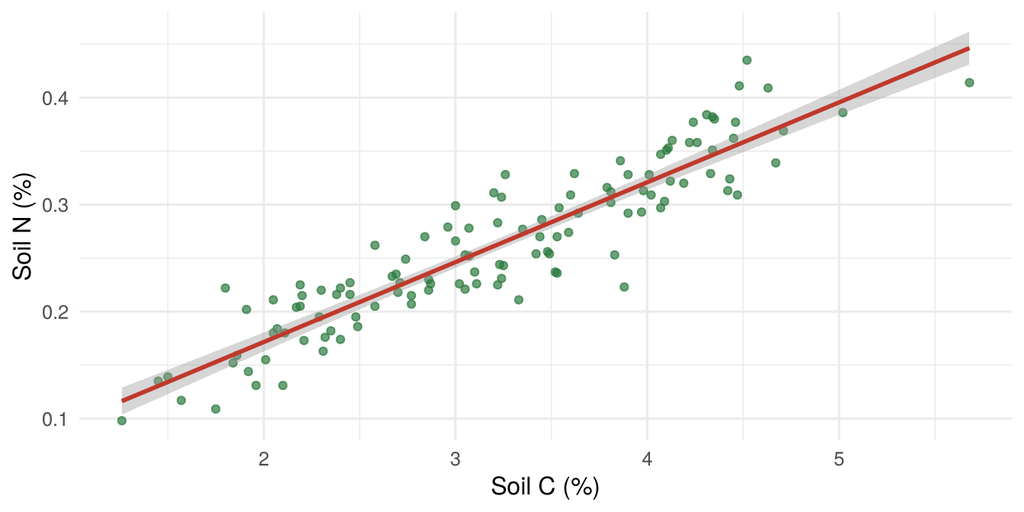

```r
ggplot(d, aes(soil_C_pct, soil_N_pct)) + geom_point(colour = green, alpha = 0.7) +
  geom_smooth(method = "lm", se = TRUE, colour = red) +
  labs(x = "Soil C (%)", y = "Soil N (%)")
```

```r
cor.test(d$soil_C_pct, d$soil_N_pct, method = "pearson")
```

```
#>
#>  Pearson's product-moment correlation
#>
#> data:  d$soil_C_pct and d$soil_N_pct
#> t = 25.3, df = 118, p-value < 2.2e-16
#> alternative hypothesis: true correlation is not equal to 0
#> 95 percent confidence interval:
#>  0.8854833 0.9428379
#> sample estimates:
#>       cor
#> 0.9188838
```

The cloud is a straight band and both variables are roughly normal, so **Pearson’s r** is the right summary: r = 0.92, a very strong positive linear relationship.

**Question 2.** Is biomass related to basal area?

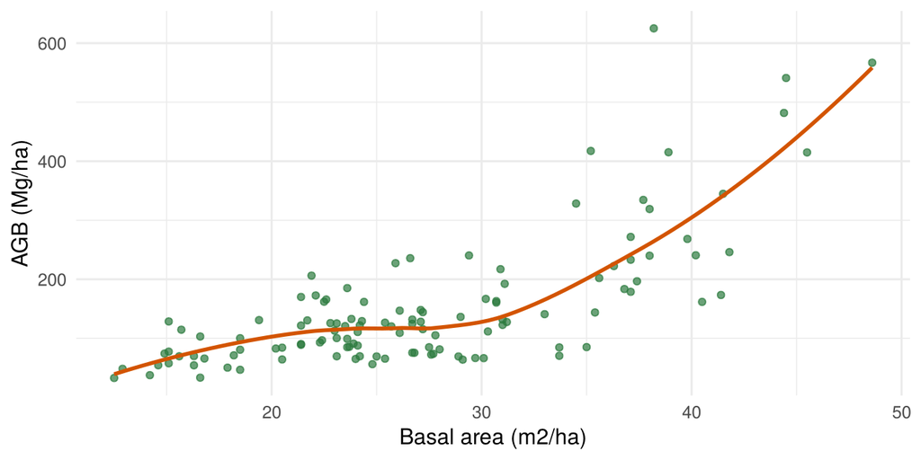

```r
ggplot(d, aes(basal_area_m2ha, agb_Mg_ha)) + geom_point(colour = green, alpha = 0.7) +
  geom_smooth(method = "loess", se = FALSE, colour = orange) +
  labs(x = "Basal area (m2/ha)", y = "AGB (Mg/ha)")
```

```r
cor.test(d$basal_area_m2ha, d$agb_Mg_ha, method = "spearman", exact = FALSE)
```

```
#>
#>  Spearman's rank correlation rho
#>
#> data:  d$basal_area_m2ha and d$agb_Mg_ha
#> S = 98752, p-value = 3.63e-16
#> alternative hypothesis: true rho is not equal to 0
#> sample estimates:
#>       rho
#> 0.6570887
```

Here the relationship is curved, biomass is skewed and a few plots are extreme. **Spearman’s rho** replaces each value by its rank, so it measures whether biomass *consistently increases* with basal area without requiring a straight line or normality.

|  | Pearson r | Spearman rho |
| --- | --- | --- |
| Measures | linear correlation | monotonic correlation (ranks) |
| Assumes | both variables ~normal, no strong outliers | only that values can be ranked |
| Use for | normal, linear data | skewed data, outliers, curved trends, ordinal scores |
| Soil C vs N | 0.92 | 0.92 |
| Basal area vs AGB | 0.73 | 0.66 |
| Basal area vs ln(AGB) | 0.75 | 0.66 |

Notice the last row: a log transformation changes Pearson’s r but **not** Spearman’s rho, because the log does not change the order of the values.

Remember that correlation is not causation, and that r measures only the *strength* of a relationship - to describe *how much* Y changes per unit of X, use regression.

## 5.2 Chi-square test for categorical variables

**Question.** Is fire history related to forest type?

Both variables are categories, so the data are **counts of plots** in a contingency table:

```r
tab <- table(d$forest_type, d$fire_history)
tab
```

```
#>
#>              Burned Unburned
#>   Agroforest     17       13
#>   Logged         14       16
#>   Plantation     23        7
#>   Primary         3       27
```

```r
chi <- chisq.test(tab)
chi
```

```
#>
#>  Pearson's Chi-squared test
#>
#> data:  tab
#> X-squared = 28.17, df = 3, p-value = 3.345e-06
```

```r
round(chi$expected, 1)     # counts expected if fire were unrelated to forest type
```

```
#>
#>              Burned Unburned
#>   Agroforest   14.2     15.8
#>   Logged       14.2     15.8
#>   Plantation   14.2     15.8
#>   Primary      14.2     15.8
```

```r
round(chi$stdres, 2)       # which cells deviate most (|value| > 2)
```

```
#>
#>              Burned Unburned
#>   Agroforest   1.16    -1.16
#>   Logged      -0.11     0.11
#>   Plantation   3.69    -3.69
#>   Primary     -4.75     4.75
```

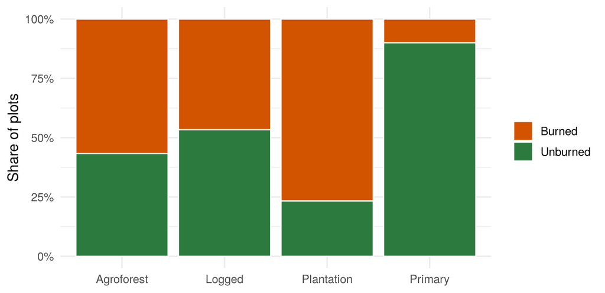

Fire history and forest type are related (chi-squared = 28.2, df = 3, p < 0.001): far fewer primary-forest plots, and more plantation plots, have burned than expected under independence.

**Rules for chi-square.**

- Use **raw counts**, never percentages or means.
- Each plot is counted once (independent observations).
- Expected counts should be at least 5 in most cells; otherwise use `fisher.test(tab)` or merge rare categories.
- A *goodness-of-fit* version compares one variable with expected proportions, e.g. `chisq.test(table(d$fire_history), p = c(0.3, 0.7))`.

> **In the app:** **5. Correlation** - the *Correlation* sub-tab shows the raw scatter (what Pearson sees) next to the rank scatter (what Spearman sees), all three coefficients side by side, and a correlation matrix. The *Chi-square* tab shows observed and expected counts, standardised residuals, Fisher’s exact test when needed, and Cramer’s V as effect size.

# 6 Regression: predicting a response

Correlation asks *“are X and Y related?”*. Regression asks *“how does Y change when X changes, and how well can X predict Y?”*. Choose the model from the **type of response variable**.

## 6.1 Linear regression (continuous response)

**Question.** How does litter depth change with canopy cover?

```r
m1 <- lm(litter_depth_cm ~ canopy_cover_pct, data = d)
summary(m1)
```

```
#>
#> Call:
#> lm(formula = litter_depth_cm ~ canopy_cover_pct, data = d)
#>
#> Residuals:
#>      Min       1Q   Median       3Q      Max
#> -2.18618 -0.53540 -0.04967  0.52092  1.73966
#>
#> Coefficients:
#>                  Estimate Std. Error t value Pr(>|t|)
#> (Intercept)      0.691557   0.360938   1.916   0.0578 .
#> canopy_cover_pct 0.042536   0.004948   8.597 4.02e-14 ***
#> ---
#> Signif. codes:  0 '***' 0.001 '**' 0.01 '*' 0.05 '.' 0.1 ' ' 1
#>
#> Residual standard error: 0.7662 on 118 degrees of freedom
#> Multiple R-squared:  0.3851, Adjusted R-squared:  0.3799
#> F-statistic: 73.91 on 1 and 118 DF,  p-value: 4.022e-14
```

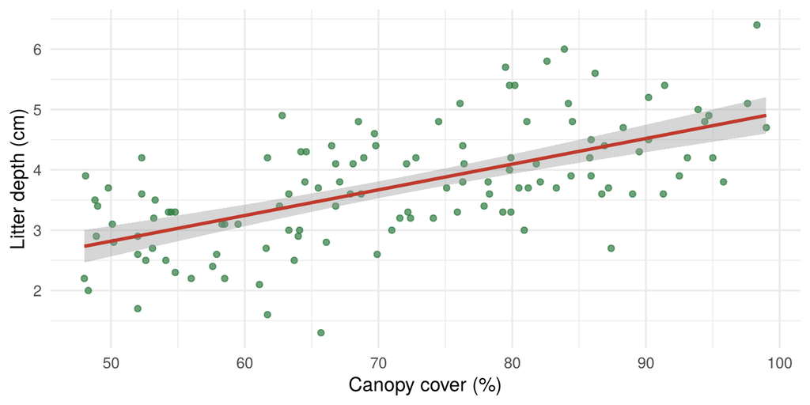

```r
ggplot(d, aes(canopy_cover_pct, litter_depth_cm)) + geom_point(colour = green, alpha = 0.7) +
  geom_smooth(method = "lm", colour = red) + labs(x = "Canopy cover (%)", y = "Litter depth (cm)")
```

**Reading the output.**

- **Slope** = 0.043: each additional 10 percentage points of canopy cover adds about 0.43 cm of litter.
- **R-squared** = 0.39: canopy cover explains 39% of the variation in litter depth.
- **p-value of the slope**: tests whether the slope differs from zero.

**Always check the diagnostics:**

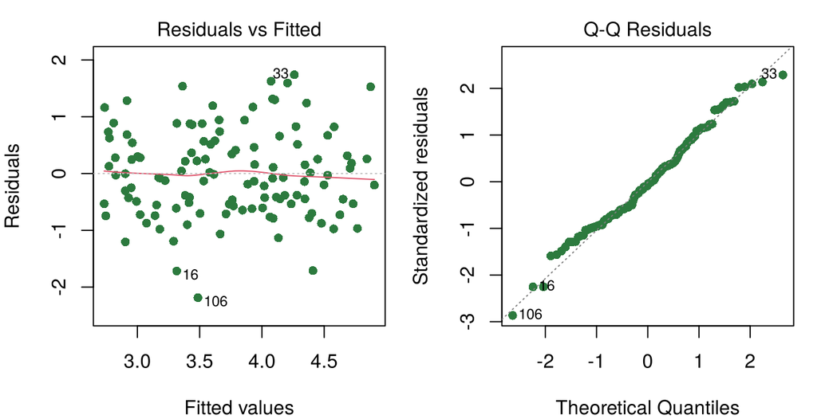

```r
par(mfrow = c(1, 2), mar = c(4, 4, 2, 1))
plot(m1, which = 1:2, pch = 16, col = green)
```

*Residuals vs Fitted* should be a shapeless cloud around zero (no curve, no funnel); the *Q-Q plot* should follow the line.

**Multiple regression** adds predictors, including categorical ones:

```r
m2 <- lm(litter_depth_cm ~ canopy_cover_pct + slope_deg + forest_type, data = d)
car::Anova(m2, type = 2)     # one test per predictor
```

|  | Sum Sq | Df | F value | Pr(>F) |
| --- | --- | --- | --- | --- |
| canopy_cover_pct | 6.9631845 | 1 | 11.6600620 | 0.0008853 |
| slope_deg | 0.8412911 | 1 | 1.4087672 | 0.2377286 |
| forest_type | 0.3063369 | 3 | 0.1709901 | 0.9157928 |
| Residuals | 68.0788005 | 114 | NA | NA |

```r
car::vif(m2)                 # collinearity check
```

```
#>                      GVIF Df GVIF^(1/(2*Df))
#> canopy_cover_pct 6.244434  1        2.498886
#> slope_deg        1.040895  1        1.020243
#> forest_type      6.276474  3        1.358165
```

Each coefficient is now the effect of that predictor *holding the others constant*. Canopy cover stays significant, while forest type adds nothing once canopy cover is known: forest types differ in litter depth mainly *because* they differ in canopy cover. The variance inflation factors (first column, about 6 for both) warn that canopy cover and forest type carry overlapping information. When VIF is well above 5, drop one of the two predictors or combine correlated predictors with a PCA (Section 7).

## 6.2 Polynomial regression (hump-shaped response)

**Question.** Understory cover is low under a closed canopy (too dark) and low in very open plots (too dry). Is there an optimum?

```r
m3 <- lm(understory_cover_pct ~ canopy_cover_pct + I(canopy_cover_pct^2), data = d)
round(coef(summary(m3)), 4)
```

```
#>                        Estimate Std. Error  t value Pr(>|t|)
#> (Intercept)           -140.8380    15.2745  -9.2204        0
#> canopy_cover_pct         5.9783     0.4358  13.7175        0
#> I(canopy_cover_pct^2)   -0.0441     0.0030 -14.6031        0
```

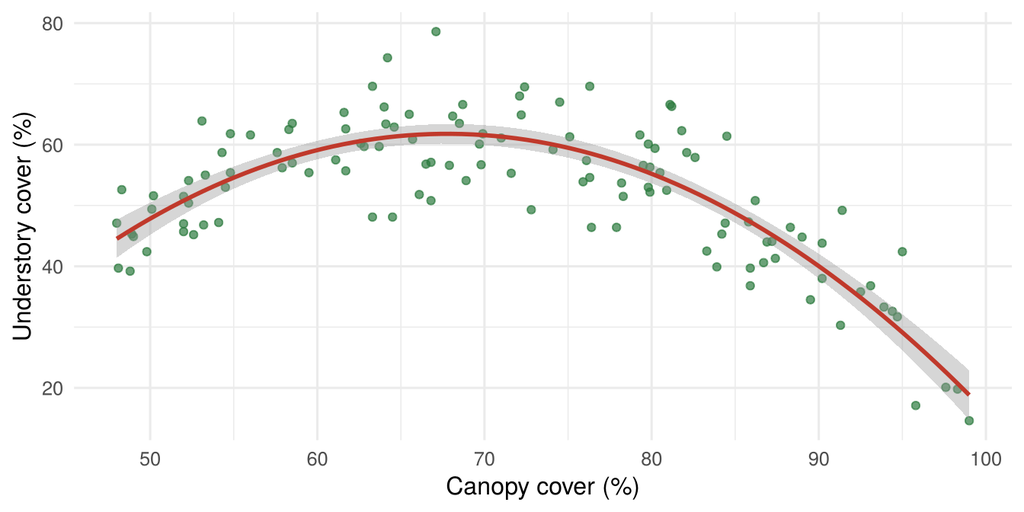

```r
ggplot(d, aes(canopy_cover_pct, understory_cover_pct)) + geom_point(colour = green, alpha = 0.7) +
  geom_smooth(method = "lm", formula = y ~ x + I(x^2), colour = red) +
  labs(x = "Canopy cover (%)", y = "Understory cover (%)")
```

The negative quadratic term makes the curve hump-shaped. The optimum is at -b1 / (2 x b2) = 68% canopy cover.

## 6.3 Poisson GLM (counts)

**Question.** Does tree species richness decline with elevation, and does it differ among forest types?

Richness is a count: it cannot be negative and its variance grows with its mean. A Poisson GLM models the *logarithm* of the expected count.

```r
m4 <- glm(species_richness ~ elevation_m + forest_type, family = poisson, data = d)
round(coef(summary(m4)), 4)
```

```
#>                       Estimate Std. Error z value Pr(>|z|)
#> (Intercept)             1.9534     0.1148 17.0134        0
#> elevation_m            -0.0009     0.0002 -5.9655        0
#> forest_typeLogged       0.5513     0.1087  5.0702        0
#> forest_typePlantation  -0.7454     0.1494 -4.9908        0
#> forest_typePrimary      0.8841     0.1046  8.4563        0
```

```r
exp(coef(m4))                                   # rate ratios
```

```
#>           (Intercept)           elevation_m     forest_typeLogged
#>             7.0526507             0.9990699             1.7355732
#> forest_typePlantation    forest_typePrimary
#>             0.4745465             2.4208382
```

```r
sum(residuals(m4, type = "pearson")^2) / df.residual(m4)   # dispersion, should be ~1
```

```
#> [1] 1.134961
```

Coefficients are on the log scale, so exponentiate them: exp(100 x -0.00093) = 0.91, i.e. richness falls by about 9% for every 100 m of elevation. Primary forest has 2.4 times the richness of agroforest (the reference level) at the same elevation.

## 6.4 Overdispersion and the negative binomial

**Question.** Do seedling counts decline with canopy cover?

```r
m5 <- glm(seedling_count ~ canopy_cover_pct, family = poisson, data = d)
disp <- sum(residuals(m5, type = "pearson")^2) / df.residual(m5)
disp
```

```
#> [1] 8.233404
```

```r
m6 <- MASS::glm.nb(seedling_count ~ canopy_cover_pct, data = d)
rbind(Poisson = coef(summary(m5))[2, ], `Neg. binomial` = coef(summary(m6))[2, ])
```

```
#>                  Estimate  Std. Error    z value     Pr(>|z|)
#> Poisson       -0.03040618 0.001870186 -16.258375 1.948382e-59
#> Neg. binomial -0.02794452 0.005404678  -5.170432 2.335528e-07
```

```r
AIC(m5, m6)
```

|  | df | AIC |
| --- | --- | --- |
| m5 | 2 | 1390.6205 |
| m6 | 3 | 848.4778 |

The dispersion statistic is 8.2, far above 1: the counts vary much more than a Poisson model allows (seedlings are clumped). The Poisson standard error is far too small. The **negative binomial** model gives a similar slope with an honest standard error and a much lower AIC.

## 6.5 Logistic regression (presence / absence)

**Question.** Does the probability of detecting a hornbill increase with basal area (large trees for nesting and fruit)?

```r
m7 <- glm(hornbill_present ~ basal_area_m2ha, family = binomial, data = d)
round(coef(summary(m7)), 4)
```

```
#>                 Estimate Std. Error z value Pr(>|z|)
#> (Intercept)      -5.1352     1.0182 -5.0434        0
#> basal_area_m2ha   0.1908     0.0378  5.0460        0
```

```r
exp(coef(m7)[2])                                # odds ratio per 1 m2/ha
```

```
#> basal_area_m2ha
#>        1.210191
```

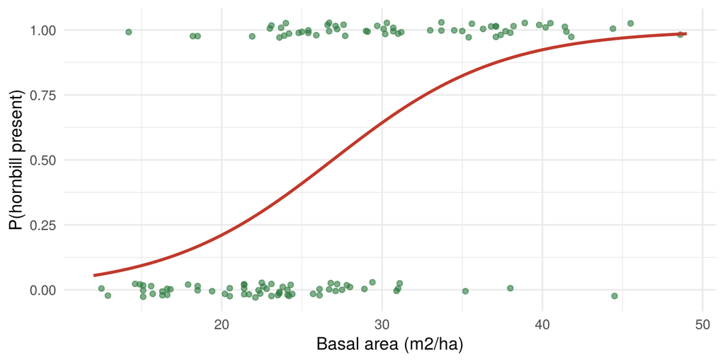

```r
nd <- data.frame(basal_area_m2ha = seq(12, 49, length.out = 100))
nd$p <- predict(m7, nd, type = "response")
ggplot(d, aes(basal_area_m2ha, hornbill_present)) +
  geom_jitter(height = 0.03, width = 0, colour = green, alpha = 0.6) +
  geom_line(data = nd, aes(y = p), colour = red, linewidth = 1) +
  labs(x = "Basal area (m2/ha)", y = "P(hornbill present)")
```

Each additional m2/ha of basal area multiplies the *odds* of hornbill presence by 1.21. The predicted probability reaches 50% at a basal area of about 27 m2/ha.

### 6.5.1 How good is the model? ROC curve and AUC

A significant slope says basal area matters; it does not say how well the model *separates* plots with and without hornbills. The **ROC curve** answers that. For every possible probability threshold it plots the share of presences correctly predicted (sensitivity) against the share of absences wrongly predicted as presences (1 - specificity). The **area under the curve (AUC)** summarises it in one number.

```r
y <- d$hornbill_present
p <- fitted(m7)                                   # predicted probabilities

# AUC: probability that a random presence gets a higher prediction than a random absence
n1 <- sum(y == 1); n0 <- sum(y == 0)
auc <- (sum(rank(p)[y == 1]) - n1 * (n1 + 1) / 2) / (n1 * n0)
auc
```

```
#> [1] 0.8234232
```

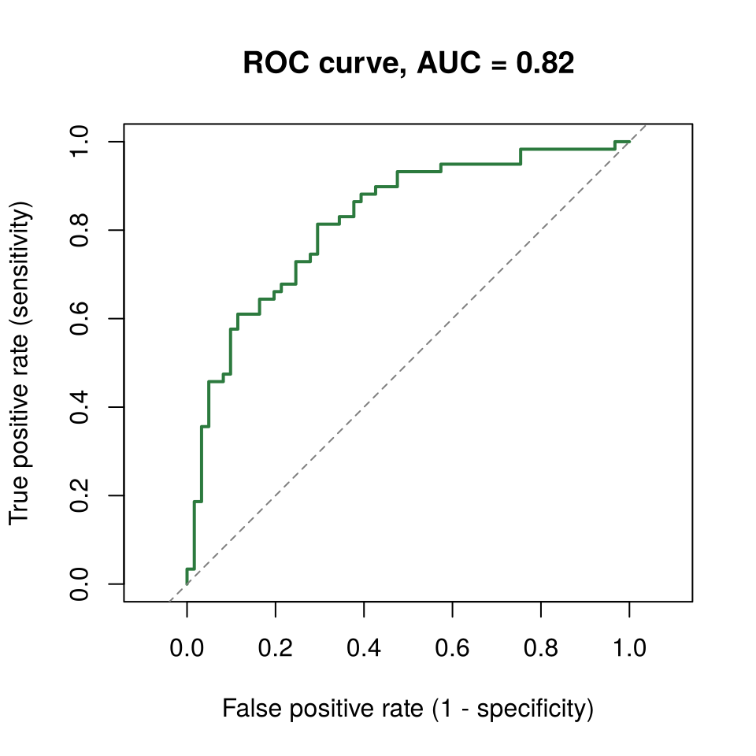

```r
# ROC curve: sensitivity and false positive rate at every threshold
thr  <- sort(unique(p), decreasing = TRUE)
sens <- sapply(thr, function(t) mean(p[y == 1] >= t))
fpr  <- sapply(thr, function(t) mean(p[y == 0] >= t))
plot(c(0, fpr), c(0, sens), type = "s", lwd = 2, col = green, asp = 1,
     xlab = "False positive rate (1 - specificity)", ylab = "True positive rate (sensitivity)",
     main = sprintf("ROC curve, AUC = %.2f", auc))
abline(0, 1, lty = 2, col = "grey50")
```

```r
# Threshold that maximises TSS (= sensitivity + specificity - 1)
best <- which.max(sens - fpr)
c(threshold = thr[best], sensitivity = sens[best],
  specificity = 1 - fpr[best], TSS = sens[best] - fpr[best])
```

```
#>   threshold sensitivity specificity         TSS
#>   0.4003638   0.8135593   0.7049180   0.5184774
```

**Reading it.** The dashed diagonal is a model no better than a coin toss (AUC = 0.5); the closer the curve hugs the top-left corner, the better. Here AUC = 0.82: picking one plot with and one without hornbills at random, the model ranks the occupied plot higher 82% of the time.

| AUC | Discrimination (Hosmer & Lemeshow) |
| --- | --- |
| 0.5 | none (chance) |
| 0.7 - 0.8 | acceptable |
| 0.8 - 0.9 | excellent |
| > 0.9 | outstanding |

Three cautions: (1) AUC computed on the data used to fit the model is optimistic - **cross-validate** to see how it does on new plots; (2) AUC measures *ranking*, not whether the probabilities themselves are right; (3) a 0/1 map needs a threshold - 0.5 is arbitrary, and ecologists often choose the one that maximises **TSS**, which is also less sensitive to how common the species is than accuracy or kappa.

> **In the app:** fit GLM → Binomial, then open **6. Regression → ROC / AUC** for the curve, AUC with 95% CI, 5-fold cross-validated AUC, and a confusion matrix at any threshold (with a one-click optimal threshold).

## 6.6 Skewed positive response: transform or Gamma GLM

```r
m8 <- lm(log(agb_Mg_ha) ~ basal_area_m2ha, data = d)                       # log-linear model
m9 <- glm(agb_Mg_ha ~ basal_area_m2ha, family = Gamma(link = "log"), data = d)  # Gamma GLM
rbind(`lm on log(AGB)` = coef(m8), `Gamma GLM` = coef(m9))
```

```
#>                (Intercept) basal_area_m2ha
#> lm on log(AGB)    3.266834      0.05712373
#> Gamma GLM         3.321797      0.05796923
```

Both say the same thing: biomass increases by about 5.9% per additional m2/ha of basal area.

| Response | Model | R |
| --- | --- | --- |
| Continuous, normal residuals | linear model | `lm(y ~ x)` |
| Count | Poisson GLM | `glm(y ~ x, family = poisson)` |
| Overdispersed count | negative binomial | `MASS::glm.nb(y ~ x)` |
| Binary 0/1 | logistic regression | `glm(y ~ x, family = binomial)` |
| Positive, right-skewed | Gamma GLM or log-LM | `glm(y ~ x, family = Gamma("log"))` |
| Any of the above, grouped data | mixed model | `lmer(y ~ x + (1 \| site))`, `glmer(...)` |

## 6.7 Random factors: mixed models

**Question.** How does canopy height increase with basal area - given that the 120 plots are grouped in 12 sites?

Plots in the same site share soil, climate and history, so they resemble each other more than plots from different sites. An ordinary regression treats all 120 plots as independent pieces of evidence, which they are not.

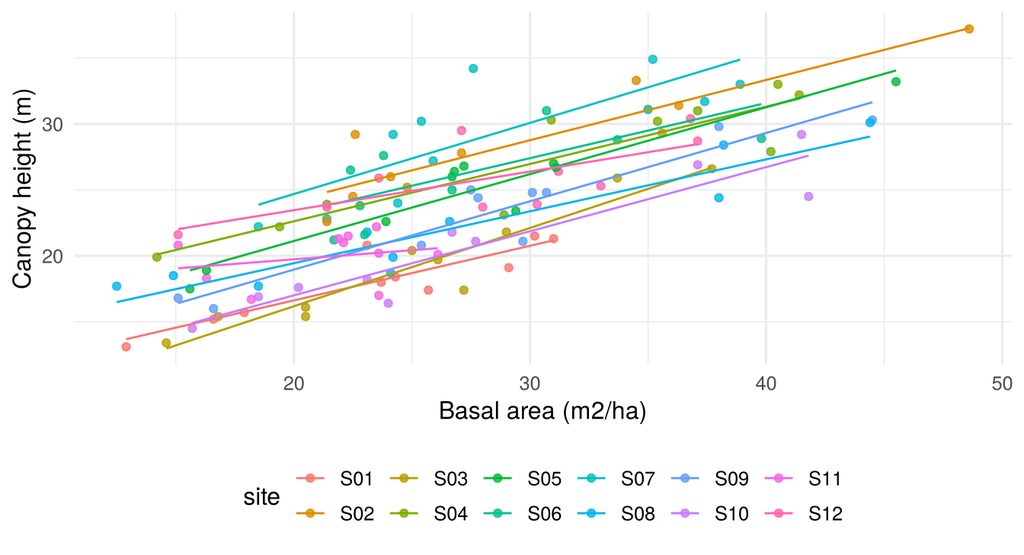

Each site has its own line: similar slopes, but some sites are consistently taller than others. A **random intercept** captures exactly that.

```r
library(lme4)
m_lm  <- lm(canopy_height_m ~ basal_area_m2ha, data = d)                 # ignores sites
m_lmm <- lmer(canopy_height_m ~ basal_area_m2ha + (1 | site), data = d)  # random intercept per site
rbind(`lm (sites ignored)` = coef(summary(m_lm))[2, 1:2],
      `lmer (site random)` = coef(summary(m_lmm))[2, 1:2])
```

```
#>                     Estimate Std. Error
#> lm (sites ignored) 0.5220858 0.03857481
#> lmer (site random) 0.4573949 0.02402882
```

```r
vc <- as.data.frame(VarCorr(m_lmm)); vc[, c("grp", "vcov", "sdcor")]
```

| grp | vcov | sdcor |
| --- | --- | --- |
| site | 8.191336 | 2.862051 |
| Residual | 3.958897 | 1.989698 |

**Reading the output.**

- The **fixed effect** (slope of basal area) is what we want to know. Its standard error is smaller in the mixed model, because the site-to-site variation is no longer mixed into the noise.
- The **random effect** is summarised by a variance, not by one coefficient per site. Here 67% of the variation that basal area does not explain lies *between sites* (intraclass correlation = 0.67).
- Ignoring grouping can mislead in both directions: for predictors that vary *within* sites (as here) you lose precision; for predictors that vary only *between* sites (e.g. site elevation) you get standard errors that are far too small - the classic pseudoreplication error.

**Fixed or random?**

| Use a **fixed** effect when… | Use a **random** factor when… |
| --- | --- |
| the levels are the ones you care about (forest type, treatment) | the levels are a sample of many possible ones (sites, blocks, observers, years) |
| you want to estimate and compare each level | you only want to account for the variation they cause |
| few levels | ideally 5 or more levels |

Counts and presence/absence work the same way with `glmer`:

```r
m_glmm <- glmer(species_richness ~ elevation_m + forest_type + (1 | site),
                family = poisson, data = d)
round(coef(summary(m_glmm)), 4)
```

```
#>                       Estimate Std. Error z value Pr(>|z|)
#> (Intercept)             1.9534     0.1149 17.0014        0
#> elevation_m            -0.0009     0.0002 -5.9597        0
#> forest_typeLogged       0.5513     0.1087  5.0701        0
#> forest_typePlantation  -0.7454     0.1494 -4.9906        0
#> forest_typePrimary      0.8841     0.1046  8.4551        0
```

```r
VarCorr(m_glmm)
```

```
#>  Groups Name        Std.Dev.
#>  site   (Intercept) 0
```

In the simulated data richness has no site effect, so the site variance is estimated at (almost) zero and the fixed effects equal those of the ordinary Poisson GLM - a mixed model costs nothing when the grouping turns out not to matter.

> **In the app:** **6. Regression** - *Model setup* (type, response, predictors, family, and optional **Random factor(s)**), *Results* (coefficients, fit statistics, dispersion check, term-level tests, VIF), *Diagnostics* (four residual plots) and *Visualise* (fitted line with confidence band, downloadable). When a random factor is chosen, Results also shows the variance components and the intraclass correlation.

# 7 Multivariate analysis

## 7.1 PCA: many environmental variables

**Question.** Six soil and structure variables are correlated with each other. Can we summarise them as one or two environmental gradients?

```r
env  <- d[, c("soil_pH", "soil_C_pct", "soil_N_pct", "litter_depth_cm",
              "canopy_cover_pct", "basal_area_m2ha")]
pca  <- prcomp(env, scale. = TRUE)      # scale. = TRUE because the units differ
summary(pca)$importance[, 1:4]
```

```
#>                             PC1       PC2       PC3       PC4
#> Standard deviation     1.949143 0.9053026 0.8245609 0.6407747
#> Proportion of Variance 0.633190 0.1366000 0.1133200 0.0684300
#> Cumulative Proportion  0.633190 0.7697900 0.8831100 0.9515400
```

```r
round(pca$rotation[, 1:2], 2)           # loadings
```

```
#>                    PC1   PC2
#> soil_pH           0.33 -0.76
#> soil_C_pct       -0.46 -0.27
#> soil_N_pct       -0.44 -0.32
#> litter_depth_cm  -0.34 -0.35
#> canopy_cover_pct -0.47 -0.02
#> basal_area_m2ha  -0.40  0.36
```

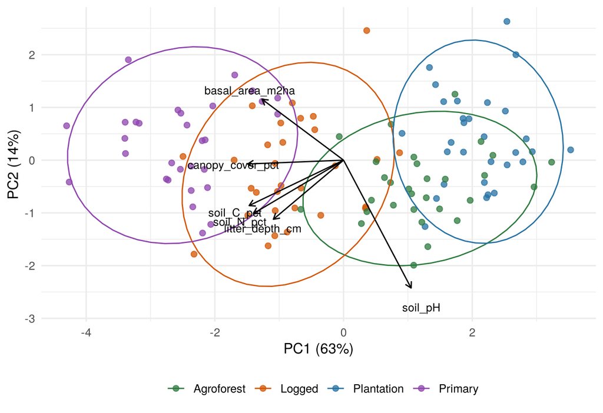

**Reading a PCA.**

- **Variance explained**: PC1 captures 63% of the total variation and PC2 another 14%. Two axes replace six variables.
- **Loadings** tell you what each axis means. Canopy cover, soil C, soil N, litter and basal area all load in the same direction on PC1, so PC1 is a “forest intactness” gradient. PC2 is mostly soil pH.
- **Biplot**: arrows pointing the same way are positively correlated; points are plots. Primary and plantation plots sit at opposite ends of PC1.
- Always **standardise** (`scale. = TRUE`) when variables have different units.
- The scores (`pca$x[, 1]`) can be used as a single predictor in a regression, which solves the collinearity problem of Section 6.

## 7.2 NMDS and PERMANOVA: species composition

**Question.** Does tree species composition differ among forest types?

Species tables are full of zeros and species respond non-linearly, so PCA is a poor tool. **NMDS** starts from a dissimilarity between every pair of plots (Bray-Curtis is the standard for abundance data) and arranges the plots so that similar plots are close together.

```r
library(vegan)
sp <- comm[, -(1:3)]                     # the 14 species columns
set.seed(123)
nmds <- metaMDS(sp, distance = "bray", k = 2, trymax = 50, autotransform = FALSE, trace = 0)
```

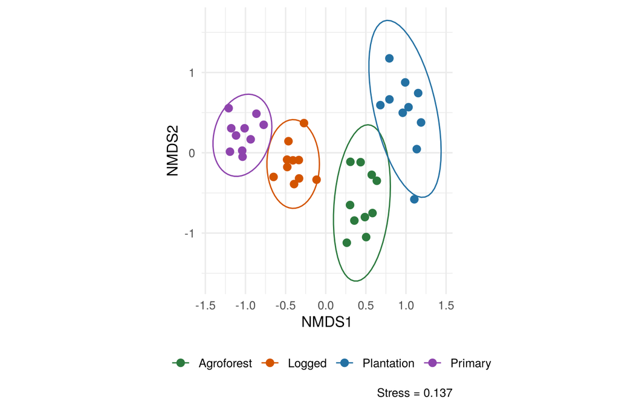

**Stress** (0.137) measures how well the 2-D map preserves the dissimilarities: below 0.1 is good, below 0.2 usable, above 0.2 unreliable. NMDS axes have no units - only relative distances matter.

The picture suggests that the forest types hold different communities. **PERMANOVA** tests it:

```r
set.seed(123)
adonis2(vegdist(sp, "bray") ~ forest_type, data = comm, permutations = 999)
```

|  | Df | SumOfSqs | R2 | F | Pr(>F) |
| --- | --- | --- | --- | --- | --- |
| forest_type | 3 | 6.408515 | 0.6190599 | 19.50101 | 0.001 |
| Residual | 36 | 3.943497 | 0.3809401 | NA | NA |
| Total | 39 | 10.352011 | 1.0000000 | NA | NA |

```r
set.seed(123)
permutest(betadisper(vegdist(sp, "bray"), comm$forest_type))   # equal spread?
```

```
#>
#> Permutation test for homogeneity of multivariate dispersions
#> Permutation: free
#> Number of permutations: 999
#>
#> Response: Distances
#>           Df  Sum Sq  Mean Sq      F N.Perm Pr(>F)
#> Groups     3 0.04809 0.016031 1.1603    999  0.321
#> Residuals 36 0.49740 0.013817
```

Forest type explains a large share of the variation in composition (R2 in the table) and the effect is significant. `betadisper` checks whether groups differ in *spread*; if it is significant, part of the PERMANOVA result may reflect differences in within-group variability rather than in average composition.

## 7.3 Cluster analysis

**Question.** Ignoring the labels, do the plots fall into natural groups?

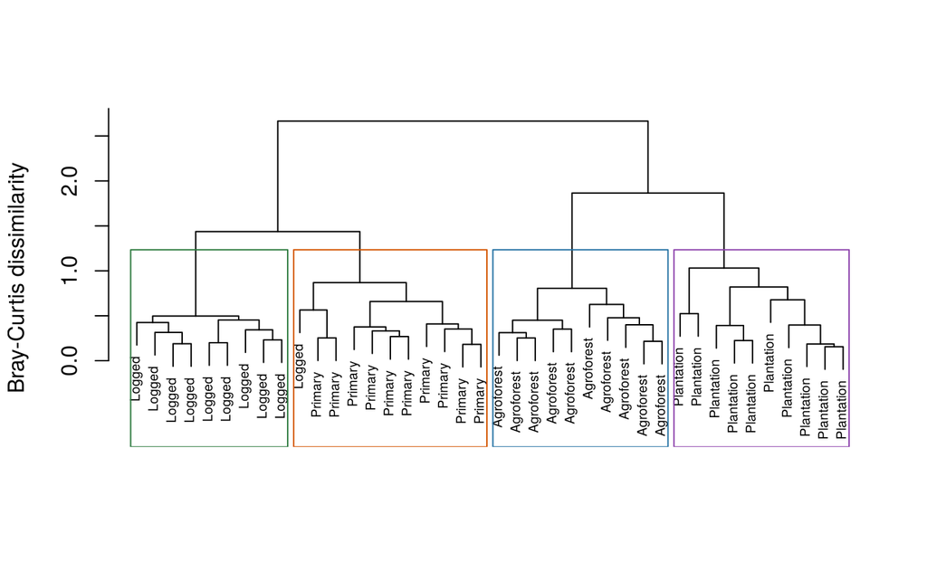

```r
hc <- hclust(vegdist(sp, "bray"), method = "ward.D2")
plot(hc, labels = comm$forest_type, cex = 0.6, main = "", xlab = "", sub = "",
     ylab = "Bray-Curtis dissimilarity")
rect.hclust(hc, k = 4, border = pal)
```

```r
table(Cluster = cutree(hc, 4), comm$forest_type)
```

```
#>
#> Cluster Agroforest Logged Plantation Primary
#>       1          0      1          0      10
#>       2          0      9          0       0
#>       3         10      0          0       0
#>       4          0      0         10       0
```

With Ward linkage the four clusters recover the four forest types almost perfectly, without ever being told the labels. The result depends on the linkage method, though: with `method = "average"` logged and primary plots merge into one cluster, because they share most of their species. Treat a dendrogram as an exploratory picture, and try more than one linkage before interpreting it.

> **In the app:** **7. Multivariate** - *PCA* (biplot, scree plot, loadings, and a button to add PC scores to the data), *NMDS + PERMANOVA* (load the “Tree community” example first) and *Cluster analysis*.

# 8 Reporting and common pitfalls

**Report four things:** the test, the test statistic with its degrees of freedom, the p-value, and an **effect size** with units (difference in means, slope, r, R-squared, odds ratio). “Primary forest had 9.3 m2/ha more basal area than logged forest (Welch t-test, t = …, df = …, p < 0.001)” tells the reader far more than “p < 0.001”.

**Pitfalls.**

1. **Pseudoreplication.** Ten subplots in one forest are not ten independent forests. The unit of replication is the unit to which the “treatment” applies. Add the grouping as a random factor (Section 6.7).
2. **Multiple testing.** Twenty tests at 0.05 produce one false positive on average. Use post-hoc corrections (Tukey, Holm) and decide your questions in advance.
3. **Significant is not important.** With many plots, tiny differences become significant; with few plots, large differences may not. Look at effect sizes and confidence intervals.
4. **“Not significant” is not “no effect”.** It means the data cannot tell.
5. **Testing assumptions on the wrong thing.** Check residuals, not raw data.
6. **Transforming counts when a GLM would do.** `log(x + 1)` on counts with many zeros behaves badly; use a Poisson or negative binomial GLM.
7. **Extrapolating.** A regression fitted between 60 and 900 m says nothing about 1500 m.

# 9 Exercises

Use the forest plot data (R or the app). Answers are hidden - try first.

**1.** Is canopy cover normally distributed (a) across all plots and (b) within each forest type? What does this tell you about checking assumptions?

**Answer**

```r
shapiro.test(d$canopy_cover_pct)$p.value
```

```
#> [1] 0.001960628
```

```r
round(sapply(split(d$canopy_cover_pct, d$forest_type), function(x) shapiro.test(x)$p.value), 3)
```

```
#> Agroforest     Logged Plantation    Primary
#>      0.046      0.708      0.040      0.531
```

Pooled, canopy cover is clearly non-normal because it mixes four groups with different means. Within each forest type the departure is much smaller (p-values around or above 0.05). Check assumptions on residuals or within groups, not on the pooled variable.

**2.** Do logged and plantation plots differ in tree density? Choose and run the test.

**Answer**

```r
ex <- droplevels(subset(d, forest_type %in% c("Logged", "Plantation")))
t.test(tree_density_ha ~ forest_type, data = ex)
```

```
#>
#>  Welch Two Sample t-test
#>
#> data:  tree_density_ha by forest_type
#> t = -4.1649, df = 56.447, p-value = 0.0001078
#> alternative hypothesis: true difference in means between group Logged and group Plantation is not equal to 0
#> 95 percent confidence interval:
#>  -117.73175  -41.26825
#> sample estimates:
#>     mean in group Logged mean in group Plantation
#>                    605.5                    685.0
```

Two independent groups and a roughly normal response: Welch’s t-test.

**3.** Does soil pH differ among forest types? Which pairs differ?

**Answer**

```r
f <- aov(soil_pH ~ forest_type, data = d); summary(f); TukeyHSD(f)$forest_type[, c("diff", "p adj")]
```

```
#>              Df Sum Sq Mean Sq F value   Pr(>F)
#> forest_type   3  8.191  2.7304   21.92 2.57e-11 ***
#> Residuals   116 14.450  0.1246
#> ---
#> Signif. codes:  0 '***' 0.001 '**' 0.01 '*' 0.05 '.' 0.1 ' ' 1
```

```
#>                              diff        p adj
#> Logged-Agroforest     -0.33433333 2.068518e-03
#> Plantation-Agroforest -0.06533333 8.901906e-01
#> Primary-Agroforest    -0.66266667 2.693107e-10
#> Plantation-Logged      0.26900000 1.972396e-02
#> Primary-Logged        -0.32833333 2.587459e-03
#> Primary-Plantation    -0.59733333 9.628430e-09
```

**4.** Is hornbill presence related to fire history? Which test, and why?

**Answer**

```r
t4 <- table(d$hornbill_present, d$fire_history); t4; chisq.test(t4); fisher.test(t4)$p.value
```

```
#>
#>     Burned Unburned
#>   0     34       27
#>   1     23       36
```

```
#>
#>  Pearson's Chi-squared test with Yates' continuity correction
#>
#> data:  t4
#> X-squared = 2.7377, df = 1, p-value = 0.09801
```

```
#> [1] 0.07122261
```

Two categorical variables -> chi-square test of independence. Neither the chi-square test nor Fisher’s exact test (preferred for a 2 x 2 table) is significant at 0.05: these data give no clear evidence that hornbill presence depends on fire history.

**5.** Correlate elevation with species richness using Pearson and Spearman. Which is more appropriate, and what would be better than either?

**Answer**

```r
c(pearson = cor(d$elevation_m, d$species_richness),
  spearman = cor(d$elevation_m, d$species_richness, method = "spearman"))
```

```
#>    pearson   spearman
#> -0.3948202 -0.3415297
```

Both show a moderate negative correlation. Richness is a count, so Spearman is the safer correlation. Better still is the Poisson GLM of Section 6: it respects the count nature of the data, gives the size of the decline per 100 m, and separates the elevation effect from the large differences among forest types.

**6.** Model seedling count as a function of canopy cover *and* forest type. Poisson or negative binomial?

**Answer**

```r
p6 <- glm(seedling_count ~ canopy_cover_pct + forest_type, family = poisson, data = d)
sum(residuals(p6, type = "pearson")^2) / df.residual(p6)
```

```
#> [1] 8.518746
```

```r
round(coef(summary(MASS::glm.nb(seedling_count ~ canopy_cover_pct + forest_type, data = d))), 3)
```

```
#>                       Estimate Std. Error z value Pr(>|z|)
#> (Intercept)              3.677      0.877   4.193    0.000
#> canopy_cover_pct        -0.017      0.013  -1.256    0.209
#> forest_typeLogged        0.041      0.272   0.151    0.880
#> forest_typePlantation    0.310      0.250   1.243    0.214
#> forest_typePrimary      -0.250      0.387  -0.647    0.518
```

The dispersion is far above 1, so use the negative binomial.

**7.** Run a PCA on the six environmental variables, add PC1 to the data and use it to predict species richness. How do you interpret the slope?

**Answer**

```r
d$PC1 <- pca$x[, 1]
round(coef(summary(glm(species_richness ~ PC1 + elevation_m, family = poisson, data = d))), 4)
```

```
#>             Estimate Std. Error  z value Pr(>|z|)
#> (Intercept)   2.2006     0.0727  30.2593        0
#> PC1          -0.2431     0.0184 -13.2149        0
#> elevation_m  -0.0010     0.0002  -6.3606        0
```

PC1 is the intactness gradient (check the sign of the loadings to see which direction is “more intact”); the slope is the change in log richness per unit of that gradient at constant elevation.

*Module and app: Hasna Afifah with Claude assistance. Example data are simulated for teaching.*